# **Sensory input and roost finding in Spix’s disc-winged bats**

### Sensory input as categorial

Bayesian MCMC generalized linear models on time (in s) to enter the roost, with individual as a random effect and sensory input treatment as predictors. An intercept-only (null) model was also included in the analysis:

1. Sensory input as a categorical variable:
   $$Time\ to\ enter\ roost \sim + categorical\ input + (1 | individual)$$
2. Null model with no predictor:
   $$Time\ to\ enter\ roost \sim 1 + (1 | individual)$$

```r
model_formulas <- c("time_to_enter ~ sensory_input_categ", "time_to_enter ~ 1")

itrns <- 100000

# Run loops with models
replic_models_categorical <- pblapply(model_formulas, function(x){

  # replicate each one 3 times
  models <- replicate(3, MCMCglmm(fixed = as.formula(x), random = ~ individual, data = dat, verbose = FALSE, nitt = itrns, start = list(QUASI = FALSE), family = "gaussian", thin = 250, burnin = 10000), simplify = FALSE)


  return(models)
})

names(replic_models_categorical) <- model_formulas

models_categorial <- model.sel(lapply(replic_models_categorical, "[[", 1), rank="DIC")

models_categorial
```

```r
replic_models_categorical <- readRDS("./output/replic_models_categorical.RDS")

models_categorial <- model.sel(lapply(replic_models_categorical, "[[", 1), rank="DIC")

models_categorial[, !colnames(models_categorial) %in% "family"]
```

|  | (Intercept) | sensory_input_categ | df | logLik | DIC | delta | weight |
| --- | --- | --- | --- | --- | --- | --- | --- |
| time_to_enter ~ sensory_input_categ | 92.6008 | + | 7 | -625.7470 | 1262.743 | 0.00000 | 1.000000e+00 |
| time_to_enter ~ 1 | 146.2027 | NA | 3 | -646.0509 | 1297.466 | 34.72328 | 2.883598e-08 |

As the model including sensory input as category provides a better fit, we proceed to evaluate it:

```r
md <- replic_models_categorical$`time_to_enter ~ sensory_input_categ`[[1]]
summary(md)
```

```
##
##  Iterations = 10001:99751
##  Thinning interval  = 250
##  Sample size  = 360
##
##  DIC: 1262.743
##
##  G-structure:  ~individual
##
##            post.mean  l-95% CI u-95% CI eff.samp
## individual      2290 1.382e-16    11449    42.38
##
##  R-structure:  ~units
##
##       post.mean l-95% CI u-95% CI eff.samp
## units     27279    16331    36543    79.88
##
##  Location effects: time_to_enter ~ sensory_input_categ
##
##                                   post.mean l-95% CI u-95% CI eff.samp   pMCMC
## (Intercept)                          92.601   25.756  162.971    460.4 0.00556
## sensory_input_categSound & vision    11.447  -86.122   96.108    360.0 0.76111
## sensory_input_categSound             -5.522 -128.148  124.859    360.0 0.97222
## sensory_input_categVision            34.558  -68.154  116.254    360.0 0.43333
## sensory_input_categLessen input     426.987  279.091  543.665    360.0 < 0.003
##
## (Intercept)                       **
## sensory_input_categSound & vision
## sensory_input_categSound
## sensory_input_categVision
## sensory_input_categLessen input   **
## ---
## Signif. codes:  0 '***' 0.001 '**' 0.01 '*' 0.05 '.' 0.1 ' ' 1
```

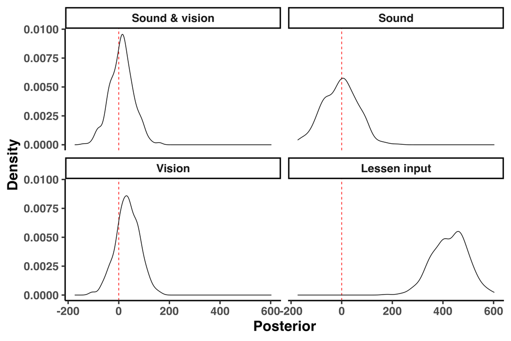

```r
colnames(md$Sol) <- gsub("sensory_input_categ", "", colnames(md$Sol))

# colnames(md$Sol)

# stack posteriors
Y <- stack(as.data.frame(md$Sol)[, -1])

# plot posteriors
ggplot(Y, aes(x=values)) +
  geom_vline(xintercept = 0, col = "red", lty = 2) +
  geom_density() +
  labs(y = "Density", x = "Posterior") +
  facet_wrap(~ ind, ncol = 2) +
  theme_classic(base_size = 24)
```

The following plot help to visualized the pattern inferred by the model:

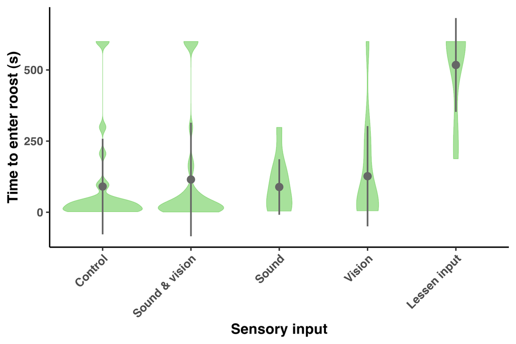

```r
agg_dat <- aggregate(time_to_enter ~ sensory_input_categ, data = dat, mean)

agg_dat$sd  <- aggregate(time_to_enter ~ sensory_input_categ, data = dat, sd)[, 2]

gg1 <- ggplot(agg_dat, aes(x = sensory_input_categ, y = time_to_enter)) +
  geom_violin(data = dat, aes(x = sensory_input_categ, y = time_to_enter), col = viridis(10, alpha = 0.6)[8], fill = viridis(10, alpha = 0.6)[8]) +
  geom_pointrange(aes(ymin = time_to_enter - sd, ymax = time_to_enter + sd), color = "gray40", size = 1.3) +
  theme(axis.text.x = element_text(angle = 45, vjust = 1, hjust = 1)) + labs(x = "Sensory input", y = "Time to enter roost (s)")

gg1
```

```r
ggsave(gg1, filename = "./output/mean_sd_and_violin_time_to_enter_by_treament.tiff", width = 7.7, height = 5.7)
```

- The only treatment category that differs significantly from the control treatment was “lessen input”